# ZADANIE 1

a) Wykonaj poniższy skrypt i przeanalizuj go:

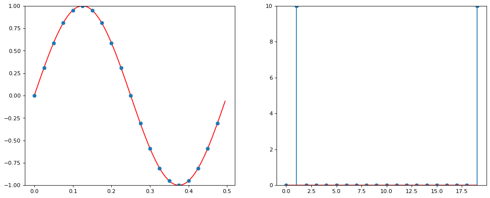

```python
from __future__ import division
from pylab import *
from scipy import *
from numpy import *
from numpy.fft import fft, ifft
from ipywidgets import *
import math as mt

%matplotlib inline

A = 1
# Amplituda sygnału

LP = 1
# Liczba analizowanych pełnych przebiegów sygnału (okresów)
w = 40
# częstotliwość probkowania [Hz] sygnału
#(jak często w ciągu sekundy pobieramy informacje o wartości sygnału)

f = 2.0
# Czestotliwosc sygnalu [Hz]

T = 1.0/f
# Okres sygnalu [s] (jak długo trwa jeden przebieg sinusa)

TW = 1.0/w
# Okres probkowania [s] (co ile sekund pobieramy próbkę)

t = np.arange(0, LP*T, TW)
# generujemy momenty, w których pobieramy próbki

n = len(t)

FUNC = lambda t : A*sin(2*pi*t*f)
# def. funkcji (tutaj sinus)

signal = FUNC(t)
# funkcja sprobkowana

fig = plt.figure(figsize=(15, 6), dpi=80)
ax = fig.add_subplot(121)
## --- POMOCNICZY SYGNAL
base_t = np.arange(0, LP*T, 1.0/200.0)
base_signal = FUNC(base_t)
ax.plot(base_t, base_signal, linestyle='-', color='red')
ax.set_ylim([min(base_signal), max(base_signal)])
## ---
ax.plot(t, signal, 'o')

signal1 = fft(signal)
# sygnal w dziedzinie czestotliwosci
signal1 = abs(signal1)
# modul sygnalu

freqs = range(int(n))


ax = fig.add_subplot(122)
ymax = max(signal1)
if (ymax > 3.0):
    ax.set_ylim([0.0,ymax])
else:
    ax.set_ylim([0.0,3.0])
stem(freqs, signal1, '-*')

show()
```

UWAGA: do dalszych ćwiczeń warto powyższy skrypt przekształcić na funkcję o wielu argumentach, typu: amplituda, częstotliwość próbkowania, liczba przebiegów. Oczywiście dla wygody, należy nadać wartości domyślne argumentom funkcji.

```python
from ipykernel.pylab.backend_inline import flush_figures

# A - Amplituda sygnału
# LP - Liczba analizowanych pełnych przebiegów sygnału (okresów)
# w - częstotliwość probkowania [Hz] sygnału
# (jak często w ciągu sekundy pobieramy informacje o wartości sygnału)
# f - Czestotliwosc sygnalu [Hz]
# Tn - Ile analizujemy okresów
# Tw - Okres probkowania [s] (co ile sekund pobieramy próbkę)
def plot_sine(A=1, LP=1, w=40, f=2.0, Tn=1, T=None):

    if T is None:
        T = Tn/f

    TW = 1.0/w

    t = np.arange(0, LP*T, TW)
    # generujemy momenty, w których pobieramy próbki

    n = len(t)

    FUNC = lambda t : A*sin(2*pi*t*f)
    # def. funkcji (tutaj sinus)

    signal = FUNC(t)
    # funkcja sprobkowana

    fig = plt.figure(figsize=(15, 6), dpi=80)
    ax = fig.add_subplot(121)
    ## --- POMOCNICZY SYGNAL
    base_t = np.arange(0, LP*T, 1.0/200.0)
    base_signal = FUNC(base_t)
    ax.plot(base_t, base_signal, linestyle='-', color='red')
    ax.set_ylim([min(base_signal), max(base_signal)])
    ## ---
    xlabel("t [s]")
    ylabel("y(t) [j]")
    ax.plot(t, signal, 'o')

    signal1 = fft(signal)
    # sygnal w dziedzinie czestotliwosci
    signal1 = abs(signal1)
    # modul sygnalu

    signal1 *= 2/n
    signal1[0] /= 2

    #freqs = range(int(n))
    freqs = arange(n)/n*w


    ax = fig.add_subplot(122)
    ymax = max(signal1)
    if (ymax > 3.0):
        ax.set_ylim([0.0,ymax])
    else:
        ax.set_ylim([0.0,3.0])

    xlabel("f [Hz]")
    ylabel("A [j]")

    stem(freqs, signal1, '-*')

    flush_figures()

interact(plot_sine, A=(0,4,0.2), LP=(1,5), w=(10,200,10), f=(1,10), T=(1,3,0.25))
```

```
<function __main__.plot_sine(A=1, LP=1, w=40, f=2.0, Tn=1, T=None)>
```

UWAGA DLA CHĘTNYCH: można wykorzystać 'interact', dzięki któremu można zmieniac parametry danej funkcji i na bieżąco obserwować zmiany. Poniższy kod przedstawia sposób wykorzystania interact:

```python
from ipykernel.pylab.backend_inline import flush_figures

def prosta(a=2, b=0):
    x = linspace(-5, 5, 100, endpoint=False) # punkty na osi OX [s]
    f = lambda x : a*x + b
    y = f(x)

    fig = plt.figure(figsize=(6, 3), dpi=80)
    ax = fig.add_subplot(111)
    ax.set_xlim(-5, 5)
    ax.set_ylim(-5, 5)
    ax.plot(x, y)
    flush_figures()

interact(prosta, a=(-5,5,0.5), b=(-5,5,0.5))
```

```
<function __main__.prosta(a=2, b=0)>
```

b) Zmień częstotliwość próbkowania na 50Hz.

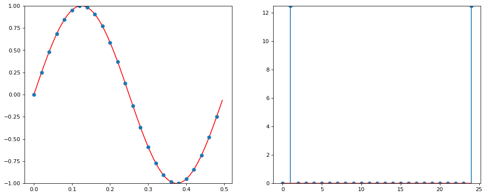

```python
# w=50
plot_sine(w=50)
```

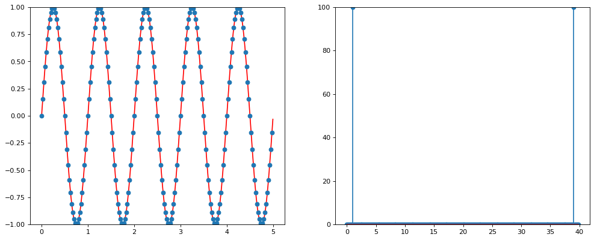

```python
# popraw oś OX
plot_sine(f=1, LP=5)
```

d) Podpisz osie obu wykresów, używając funkcji xlabel() i ylabel(). Pamiętaj o jednostkach.

```python
# Podpisz osie wykresów
```

f) Porównaj spektrum funkcji $sin(2*pi*f*t)$, $2*sin(2*pi*f*t)$ i $3*sin(2*pi*f*t)$. Jak zmienia się wartość na osi OY na wykresie spektrum?

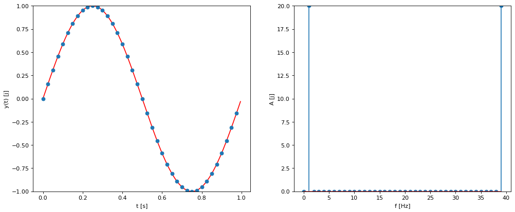

```python
# f=1, A=1, LP=1
plot_sine(f=1, A=1, LP=1)
```

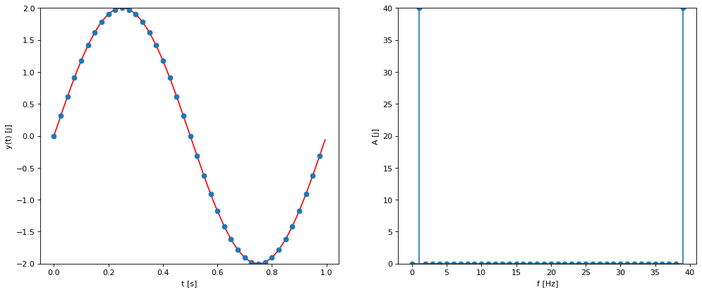

```python
# f=1, A=2, LP=1
plot_sine(f=1, A=2, LP=1)
```

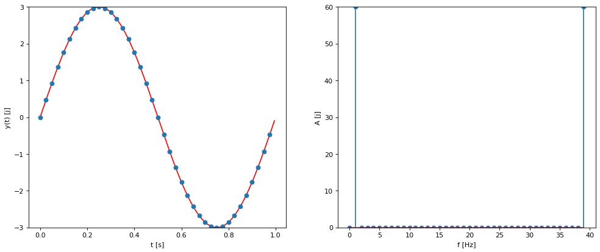

```python
# f=1, A=3, LP=1
plot_sine(f=1, A=3, LP=1)
```

Odp.: Amplituda na spektrum rośnie wprost proporcjonalnie do amplitudy sygnału

g) Ile punktów jest na wykresach przy częstotliwości próbkowania 50Hz, T=1s? Zwiększ dwukrotnie liczbę próbek poprzez zwiększenie częstotliwości próbkowania. Następnie: dla $sin(2*pi*f*t)$ porównaj wartość na osi OY spektrum uzyskane w tym oraz poprzednim punkcie.

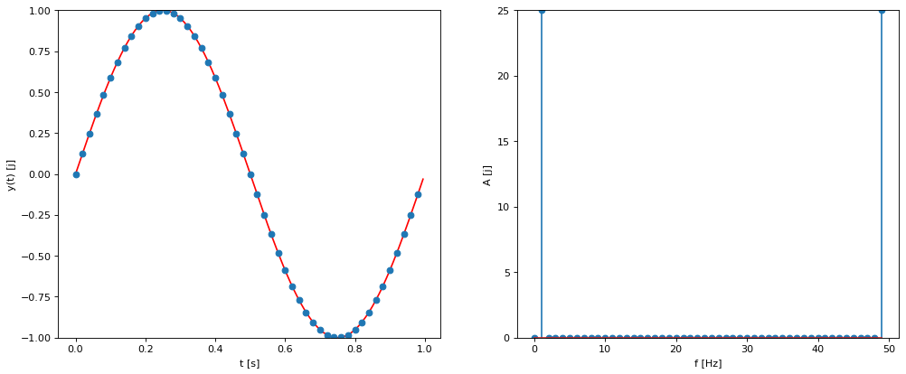

```python
# f=1, w=50, LP=1
plot_sine(f=1, w=50, LP=1)
```

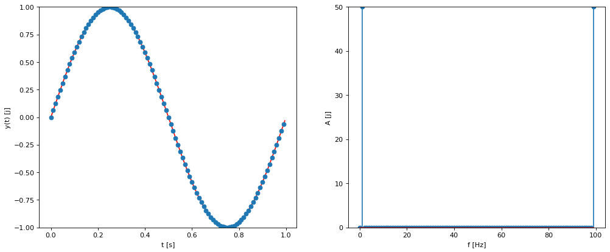

```python
# f=1, w=100, LP=1
plot_sine(f=1, w=100, LP=1)
```

Odp.: Amplituda jest wprost proporcjonalna do liczby próbek (dla A=1 jest równa jej połowie)

h) Na podstawie wyników uzyskanych w dwóch poprzednich punktach przeskaluj oś OY spektrum tak, aby wskazywała wartości amplitud badanych sygnałów. Sprawdź wyniki dla kilku wybranych funkcji.

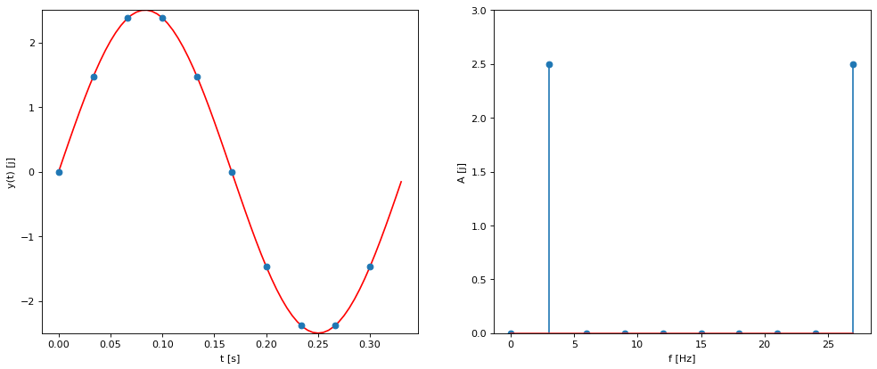

```python
# popraw oś OY
plot_sine(A=2.5, f=3, w=30)
```

# Zadanie 2

a) Wygeneruj spektrum dla funkcji sinus o częstotliwościach 5Hz i 21Hz, dla czestotliwości próbkowania 20Hz i 20 (LP=20) analizowanych przebiegów. Czy rozpoznajesz te funkcje patrząc na ich spróbkowane wykresy? Odczytaj w drugim przypadku uzyskaną częstotliwość z FFT. Dlaczego uzyskano taki wynik?

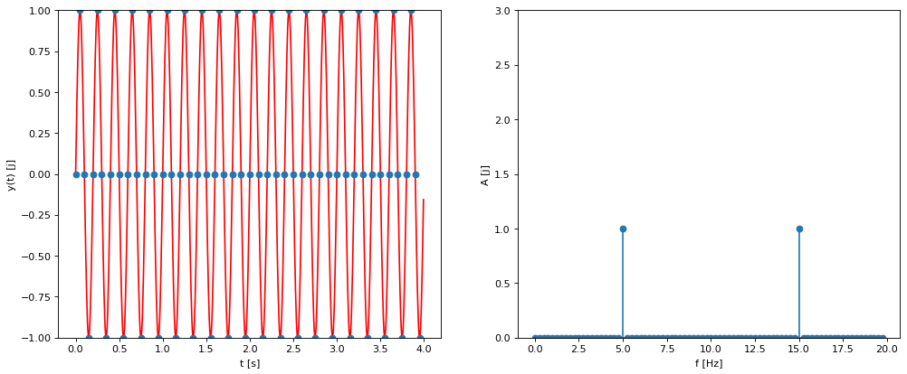

```python
# f=5, w=20, LP=20
plot_sine(f=5, w=20, LP=20)
```

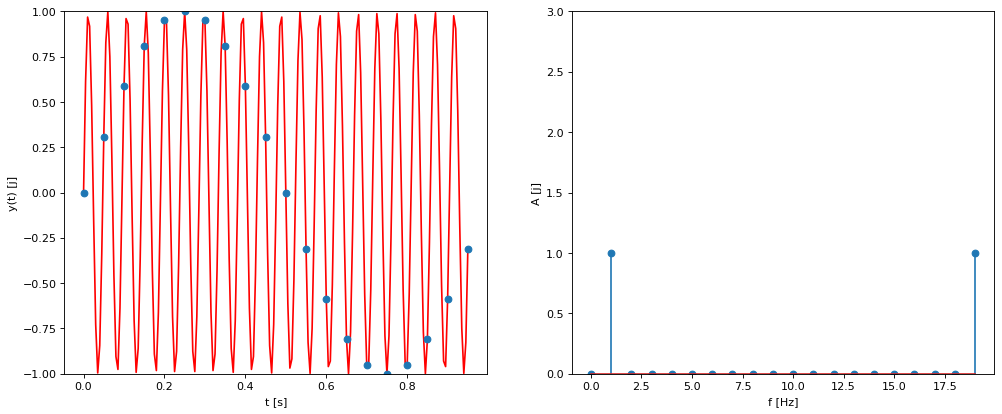

```python
# f=21, w=20, LP=20
plot_sine(f=21, w=20, LP=20)
```

Zwróć uwagę, że spektrum jest symetryczne (poza pierwszym elementem).

Odp.: Uzyskano wynik jak dla funkcji o częstotliwości $f_1 = f\,mod\,w = 1\text{Hz}$. Jest on inny niż można by się było spodziewać, ponieważ $f$ jest większe od częstotliwości Nyquista.

b) Przy w=100Hz, przeanalizuj widma sygnałów:

i) $sin(2*pi*t*f)$, $f=10Hz$

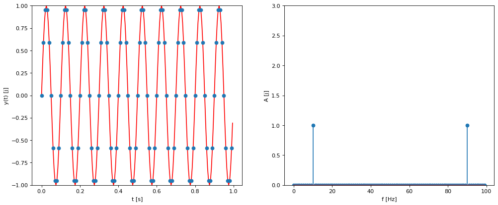

```python
# f=10, w=100, A=1, LP=10
plot_sine(f=10, w=100, A=1, LP=10)
```

ii) $sin(2*pi*t*f)$, $f=20Hz$

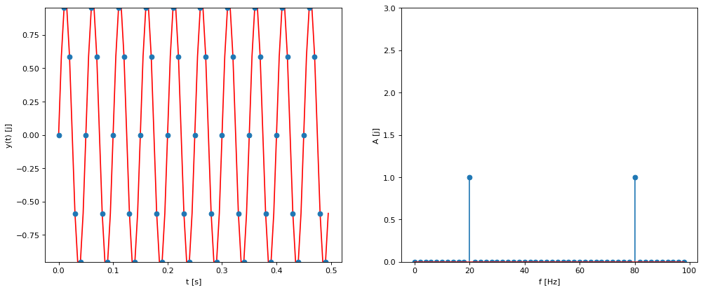

```python
# f=20, w=100, A=1, LP=10
plot_sine(f=20, w=100, A=1, LP=10)
```

iii) $sin(2*pi*t*f)$, $f=30Hz$ (tutaj słupki nie będą wyglądać idealnie; dlaczego?)

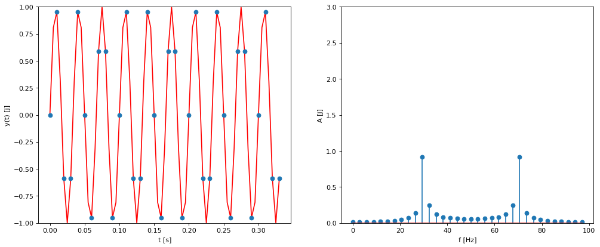

```python
# f=30, w=100, A=1, LP=10
plot_sine(f=30, w=100, A=1, LP=10)
```

Odp.: Słupki nie wyglądają idealnie, ponieważ $\frac{LP\cdot w}{f} \notin \mathbb{Z}$

iv) $sin(2*pi*t*f)$, $f=40Hz$

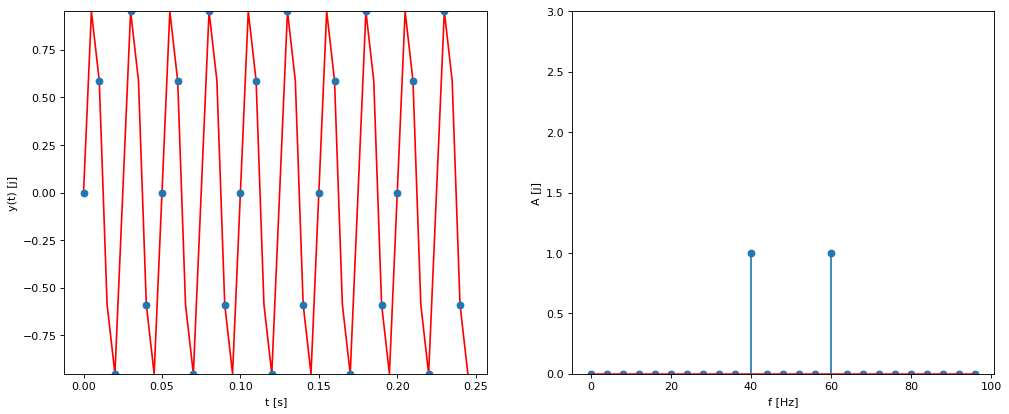

```python
# f=40, w=100, A=1, LP=10
plot_sine(f=40, w=100, A=1, LP=10)
```

c) Przy F=50Hz, w=100Hz, wygeneruj spektrum dla $sin(2*pi*f*t)$. Zwróć uwagę na skalę wykresów.

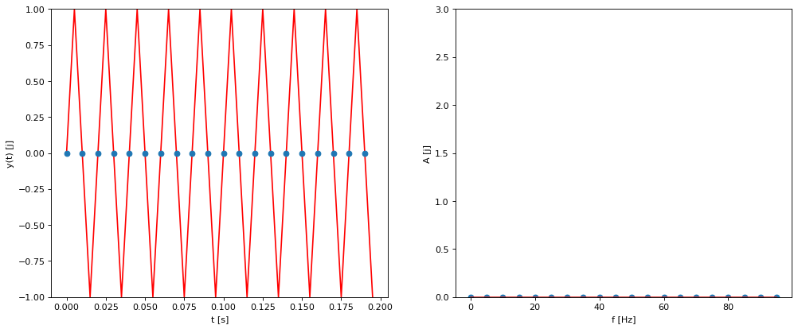

```python
# f=50, w=100, A=1, LP=10
plot_sine(f=50, w=100, A=1, LP=10)
```

c) Jak się nazywa twierdzenie, którego konsekwencją jest takie zachowanie się spektrum?

Odp.: Twierdzenie Nyquista-Shannona.

# Zadanie 3

Poniższe przypadki skłądają się z złożonych sygnałów. Trzeba teraz będzie zmodyfikować trochę FUNC

a) $sin(2*pi*t*f) + 2*sin(4*pi*t*f)$, T=1s, w=20Hz.

```python
import builtins as bi

def plot_func(FUNC, LP=1, w=50, T=1, ang=False):
    TW = 1.0/w

    t = np.arange(0, LP*T, TW)
    # generujemy momenty, w których pobieramy próbki

    n = len(t)

    signal = FUNC(t)
    # funkcja sprobkowana

    fig = plt.figure(figsize=(15, 6), dpi=80)
    ax = fig.add_subplot(121)
    ## --- POMOCNICZY SYGNAL
    base_t = np.arange(0, LP*T, 1.0/200.0)
    base_signal = FUNC(base_t)
    ax.plot(base_t, base_signal, linestyle='-', color='red')
    ax.set_ylim([min(base_signal), max(base_signal)])
    ## ---
    xlabel("t [s]")
    ylabel("y(t) [j]")
    ax.plot(t, signal, 'o')

    freqs = arange(n)/n*w
    ax = fig.add_subplot(122)

    xlabel("f [Hz]")

    if ang:
        signal1 = angle(fft(signal), deg=True)
        ylabel(r"$\varphi$ [deg]")
    else:
        signal1 = fft(signal)
        # sygnal w dziedzinie czestotliwosci
        signal1 = abs(signal1)
        # modul sygnalu

        signal1 *= 2/n
        signal1[0] /= 2
        ymax = max(signal1)
        if (ymax > 3.0):
            ax.set_ylim([0.0,ymax])
        else:
            ax.set_ylim([0.0,3.0])

        ylabel("A [j]")

    stem(freqs, signal1, '-*')

    flush_figures()

def sines_func(lA=[1], lf=[2.0], lph=None):
    if lph is None:
        lph = [0]*len(lf)
    FUNC = lambda t : bi.sum(A*sin(2*pi*t*f+p) for A,f,p
                             in zip(lA, lf, lph))
    return FUNC
def plot_sines(lA=[1], lf=[2.0], lph=None, LP=1, w=50, T=1, **kwargs):
    plot_func(sines_func(lA, lf, lph), LP=LP, w=w, T=T, **kwargs)
```

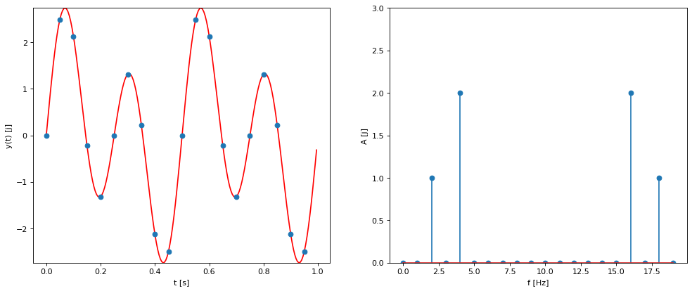

```python
# Wyrysuj sygnał
plot_sines(lA=[1, 2], lf=[2, 4], w=20)
```

c) Wygenerujemy trochę szumu. Wychodząc z funkcji sin(2*pi*t*f), dodamy do niej 100 losowych sinusów. Wygenerujemy dla nich losowo amplitudy (z [0.02, 0.08], częstotliwosci: [5.0, 10.0] oraz modyfikacje fazy[0 + 2*pi]. Inne parametry: w=20Hz, T=1s. Czy dla powyższych paramerów losowania, jesteś w stanie odnaleźć bazowy przebieg (sin(2*pi*t))? Czy jesteś w stanie zlokalizować szum?

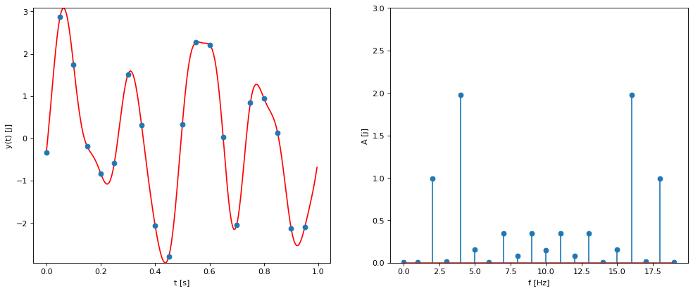

```python
def plot_sines_noise(lA=[1], lf=[2.0], lph=None, LP=1, w=50, T=1, sh=(100,), nsc=1):
    if lph is None:
        lph = [0]*len(lf)
    def randr(a=0, b=1):
        return a+random.random(sh)*(b-a)
    FUNC = sines_func(
            [*lA, *randr(0.02, 0.08)*nsc],
            [*lf, *randr(5, 10)],
            [*lph, *randr(0, 2*pi)])
    plot_func(FUNC, LP=LP, w=w, T=T)

plot_sines_noise(lA=[1, 2], lf=[2, 4], w=20)
```

Odp.: Bazowym częstotliwościom odpowiadają słupki o dużych wartościach amplitud (tu: >=1.0), a szumowi - te poniżej.

d) $0.5 + 2*sin(2*pi*t*f)$, T=1s, w=20Hz. Czy amplituda zerowego prążka jest prawidłowa? Dlaczego? (Podpowiedź: zwróć jeszcze raz uwagę na “symetrię” spektrum).

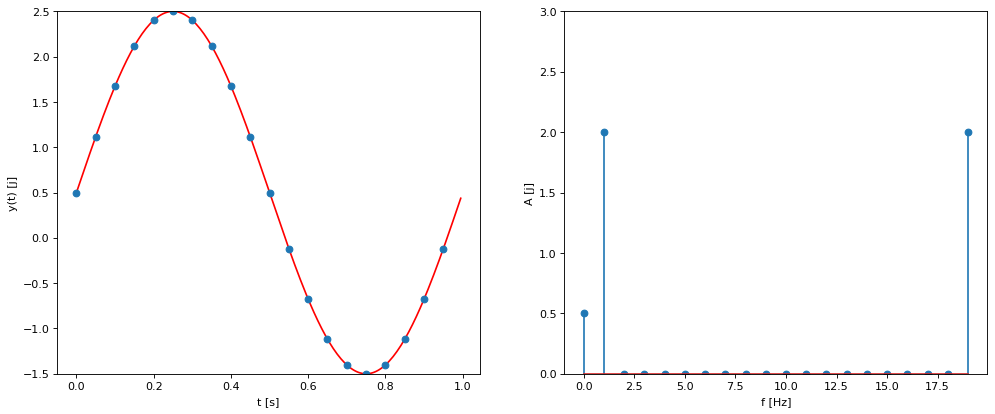

```python
# Wyrysuj sygnał
plot_sines(lA=[0.5, 2], lf=[0, 1], lph=[pi/2, 0], w=20)
```

Odp.: Amplituda zerowego prążka była 2 razy za duża, ponieważ słupek dla f=0Hz pokrywa się ze swoim symetrycznym odbiciem, tj. 20Hz.

e) $sin(2*pi*t*f)$ oraz $sin(2*pi*t*f + pi/4)$ dla T=1s, w=20Hz. Czy informacja o fazie zniknęła? Poszukaj śladów tej informacji w tablicy, będącej wynikiem operacji fft(signal). (funkcja angle(sygnal, deg=True)

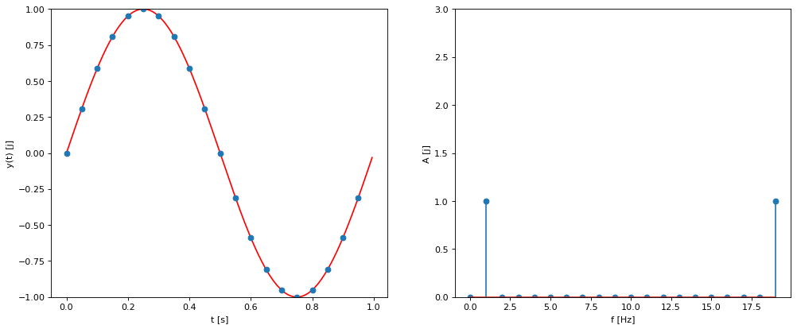

```python
# faza = 0
plot_sines(lf=[1], w=20)
```

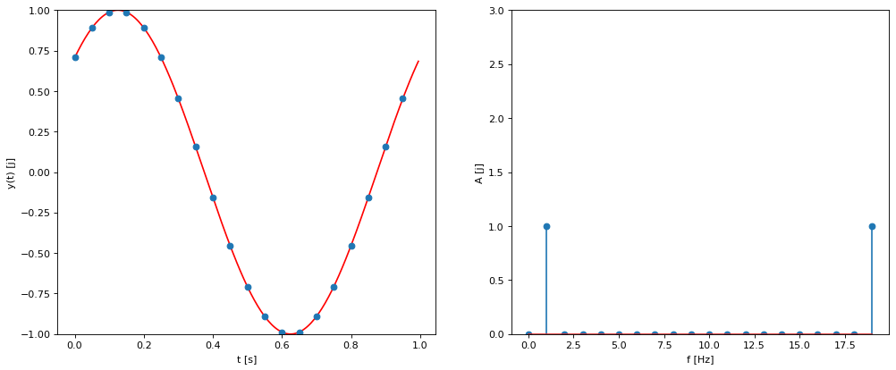

```python
# faza = pi/4
plot_sines(lf=[1], lph=[pi/4], w=20)
```

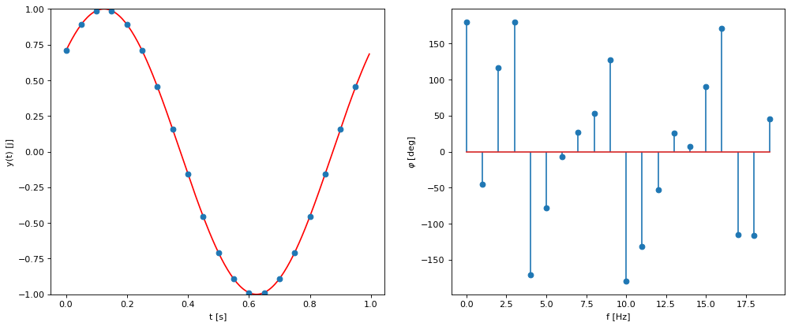

```python
plot_sines(lf=[1], lph=[pi/4], w=20, ang=True)
```

Odp.: Informacja o fazie jest widoczna na słupkach (1, -45) i (19, 45).

# Zadanie 4

Oblicz wynik ifft(fft(x)), gdzie x=random.random(10). Czy jakaś informacja została stracona?

```python
# wygeneruj wektor x
x = random.random(10)
```

```python
# oblicz fft z x
ff = fft(x)
```

```python
# oblicz ifft
x1 = ifft(ff)
```

```python
#porownaj x z ifft(fft(x)), wystarczy print
for a, b in zip(x, x1):
    print(a, "=", b)
```

```
0.03150573604360252 = (0.031505736043602565-5.551115123125783e-18j)
0.5433161613383857 = (0.5433161613383857+5.551115123125783e-18j)
0.05885909977996173 = (0.05885909977996173-5.551115123125783e-18j)
0.14266277200372302 = (0.14266277200372307+5.551115123125783e-18j)
0.2429285384217107 = (0.2429285384217108-5.551115123125783e-18j)
0.4977104018581008 = (0.4977104018581009+5.551115123125783e-18j)
0.7394638800610208 = (0.7394638800610208-5.551115123125783e-18j)
0.6039831396060014 = (0.6039831396060014+5.551115123125783e-18j)
0.005780996174081232 = (0.0057809961740812104-5.551115123125783e-18j)
0.9296914770092234 = (0.9296914770092233+5.551115123125783e-18j)
```